# Narovonna

2022-05-30

## Analiza danych dotyczących ataków z użyciem broni palnej w Zjednoczonych Stanach Ameryki na przestrzeni lat 2013-2022

### 1. Przygotowanie danych do analizy

#### 1.1 Wczytanie potrzebnych pakietów

```r
defaultW <- getOption("warn")
options(warn = -1)
library(ggplot2)
library(dplyr)
library(ggthemes)
library(extrafont)
library(readr)
library(readxl)
library(reshape2)
library(viridis)
library(tidyr)
```

#### 1.2 Wgranie danych, na których będziemy operować

Jest to baza danych zawierająca informacje dotyczące ataków z użyciem broni palnej w latach 2013-2022 uzupełniona o informacje takie jak: numer zdarzenia, data, stan, miasto, adres, liczba osób zabitych oraz liczba osób rannych. Ostatnia aktualizacja z dnia 29.05.2022.

```r
strzelaniny <- read_excel("C:/Users/edyta/Desktop/all_incidents.xlsx")
```

#### 1.3 Usunięcie z bazy pustych kolumn

```r
strzelaniny <- strzelaniny[,-c(8:10)]
glimpse(strzelaniny)
```

```
## Rows: 472,820
## Columns: 7
## $ incident_id <dbl> 2314858, 2314409, 2314498, 2314485, 2314483, 2314481, 2314~
## $ date        <dttm> 2022-05-28, 2022-05-28, 2022-05-28, 2022-05-28, 2022-05-2~
## $ state       <chr> "Arkansas", "Colorado", "Missouri", "South Carolina", "Cal~
## $ city        <chr> "Little Rock", "Denver", "Saint Louis", "Florence", "Carmi~
## $ address     <chr> "W 9th St and Broadway St", "3300 block of Clay St", "Page~
## $ n_killed    <dbl> 0, 0, 0, 0, 1, 0, 0, 0, 2, 1, 0, 0, 0, 1, 1, 0, 0, 1, 0, 1~
## $ n_injured   <dbl> 1, 1, 1, 2, 0, 1, 1, 2, 0, 2, 1, 1, 1, 0, 0, 1, 1, 0, 1, 2~
```

#### 1.4 Zmiana nazw zmiennych

```r
strzelaniny <- rename(strzelaniny,
                      numer_zdarzenia = incident_id,
                      data = date,
                      stan = state,
                      miasto = city,
                      adres = address,
                      liczba_zabitych = n_killed,
                      liczba_zranionych = n_injured)
names(strzelaniny)
```

```
## [1] "numer_zdarzenia"   "data"              "stan"
## [4] "miasto"            "adres"             "liczba_zabitych"
## [7] "liczba_zranionych"
```

#### 1.5 Wybranie do analizy 10 najbardziej zaludnionych Stanów

10 najbardziej zaludnionych stanów będzie wykorzystywanych do przeprowadzania analizy w rozdziałach 2-4

```r
stany <- c("California", "Texas", "New York", "Florida", "Pennsylvania", "Illinois", "Ohio", "Michigan", "Georgia", "North Carolina")
strzelaniny1 <- strzelaniny %>% filter(stan %in% stany)
```

### 2. Analiza liczby ofiar śmiertelnych w 10 najbardziej zaludnionych stanach

Pierwsza analiza zostanie przeprowadzona na zmiannych stany i liczba_zabitych

#### 2.1 Utworzenie ramki danych ze zmiennych stany oraz liczba zabitych wraz ze zsumowaniem liczby zabitych dla każdego stanu

```r
strzelaniny1 <- strzelaniny1 %>% filter(liczba_zabitych > 0)
stanyOfiary <- strzelaniny1 %>% group_by(stan) %>% summarise(liczba_zabitych = sum(liczba_zabitych)) %>%  as.data.frame()
stanyOfiary <- arrange(stanyOfiary, liczba_zabitych, stany)
stanyOfiary
```

```
##              stan liczba_zabitych
## 1        New York            3838
## 2        Michigan            3869
## 3  North Carolina            4986
## 4    Pennsylvania            5597
## 5            Ohio            5610
## 6         Georgia            5678
## 7        Illinois            7532
## 8         Florida            8281
## 9           Texas           11865
## 10     California           11892
```

#### 2.2 Przypisanie kolejności dla wartości w ramce danych celem utworzenia wykresu

```r
stanyOfiary$stan <- factor(stanyOfiary$stan, levels = stanyOfiary$stan[order(stanyOfiary$liczba_zabitych)])
```

#### 2.3 Utworzenie wykresu słupkowego

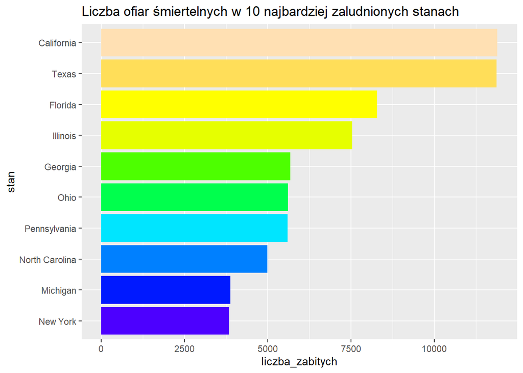

```r
wykresOfiary <- ggplot(stanyOfiary, aes(x = stan, y = liczba_zabitych)) + geom_col(fill = topo.colors(10)) +  coord_flip() + ggtitle("Liczba ofiar śmiertelnych w 10 najbardziej zaludnionych stanach")
wykresOfiary
```

#### 2.4 Wskazanie stanu z największą liczbą ofiar śmiertelnych

```r
top_n(stanyOfiary, 1)
```

```
##         stan liczba_zabitych
## 1 California           11892
```

#### 2.4 Wskazanie stanu z najmniejszą liczbą ofiar śmiertelnych

```r
top_n(stanyOfiary, -1)
```

```
##       stan liczba_zabitych
## 1 New York            3838
```

### 3. Analiza liczby rannych ofiar w 10 najbardziej zaludnionych stanach

Druga analiza zostanie przeprowadzona na zmiennych stany i liczba_zranionych

#### 3.1 Utworzenie ramki danych ze zmiennych stany oraz liczba zranionych wraz ze zsumowaniem liczby zranionych dla każdego stanu

```r
strzelaniny2 <- strzelaniny1 %>% filter(liczba_zranionych > 0)
stanyRanni <- strzelaniny2 %>% group_by(stan) %>% summarise(liczba_zranionych = sum(liczba_zranionych)) %>%  as.data.frame()
stanyRanni <- arrange(stanyRanni, liczba_zranionych, stany)
stanyRanni
```

```
##              stan liczba_zranionych
## 1        Michigan               907
## 2        New York               941
## 3  North Carolina              1043
## 4    Pennsylvania              1166
## 5            Ohio              1194
## 6         Georgia              1199
## 7         Florida              1915
## 8        Illinois              2234
## 9           Texas              2414
## 10     California              2749
```

#### 3.2 Przypisanie kolejności dla wartości w ramce danych celem utworzenia wykresu

```r
stanyRanni$stan <- factor(stanyRanni$stan, levels = stanyRanni$stan[order(stanyRanni$liczba_zranionych)])
```

#### 3.3 Utworzenie wykresu słupkowego

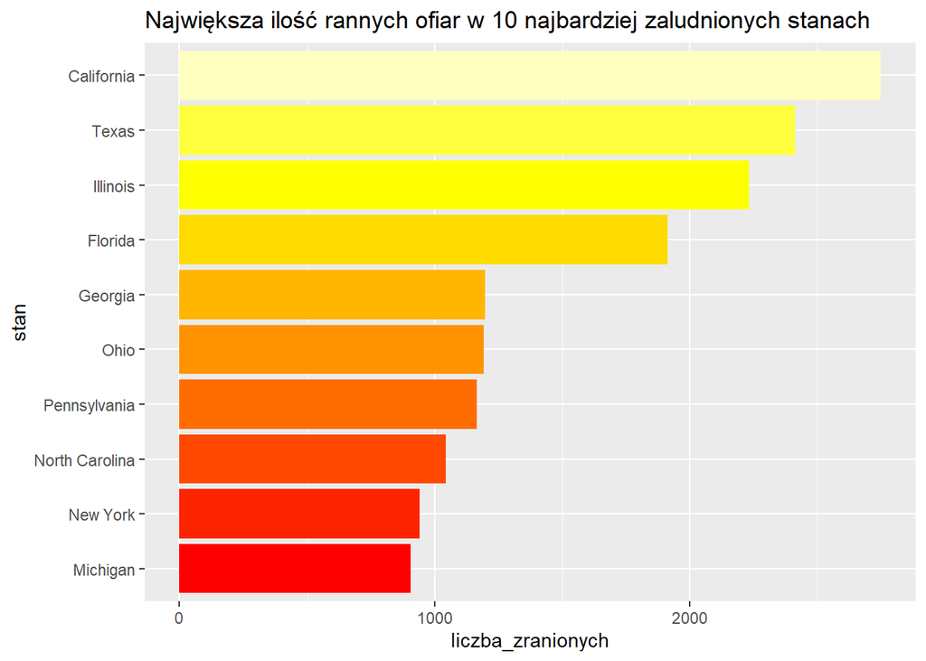

```r
wykresRanni <- ggplot(stanyRanni, aes(x = stan, y = liczba_zranionych )) + geom_col(fill = heat.colors(10)) +  coord_flip() + ggtitle("Największa ilość rannych ofiar w 10 najbardziej zaludnionych stanach")
wykresRanni
```

#### 3.4 Wskazanie stanu z największą liczbą rannych ofiar

```r
top_n(stanyRanni, 1)
```

```
##         stan liczba_zranionych
## 1 California              2749
```

#### 3.5 Wskazanie stanu z najmniejszą liczbą rannych ofiar

```r
top_n(stanyRanni, -1)
```

```
##       stan liczba_zranionych
## 1 Michigan               907
```

### 4. Analiza liczby masowych strzelanin w 10 najbardziej zaludnionych stanach

Przyjęte zostało, że terminem masowa strzelanina określa się zdarzenia, w którym trafionych z broni zostaje więcej niż trzy osoby. W tym przypadku masową strzelaniną będzie określane zdarzenie, w którym więcej niż trzy osoby zostały zranione lub zabite.

#### 4.1 Przygotowanie zmiennej liczba_trafionych i ustalenie kryteriów w celu przeprowadzenia analizy

```r
strzelaniny3 <- strzelaniny %>% filter(stan %in% stany)
strzelaniny3 <- strzelaniny3 %>% mutate(liczba_trafionych = liczba_zabitych+liczba_zranionych)
strzelaniny3 <- strzelaniny3 %>% filter(liczba_trafionych > 3)
```

#### 4.2 Utworzenie ramki danych ze zmiennych stany oraz liczba masowych strzelanin wraz ze zsumowaniem liczby masowych strzelanin

```r
masowe <- strzelaniny3 %>% group_by(stan) %>% summarise(liczba_masowych = length(liczba_trafionych)) %>%  as.data.frame()
masowe <- arrange(masowe, liczba_masowych, stany)
masowe
```

```
##              stan liczba_masowych
## 1        Michigan             146
## 2  North Carolina             162
## 3            Ohio             183
## 4         Georgia             187
## 5        New York             201
## 6    Pennsylvania             212
## 7         Florida             284
## 8           Texas             349
## 9      California             448
## 10       Illinois             452
```

#### 4.3 Przypisanie kolejności dla wartości w ramce danych

```r
masowe$stan <- factor(masowe$stan, levels = masowe$stan[order(masowe$liczba_masowych)])
```

#### 4.4 Utworzenie wykresu punktowego

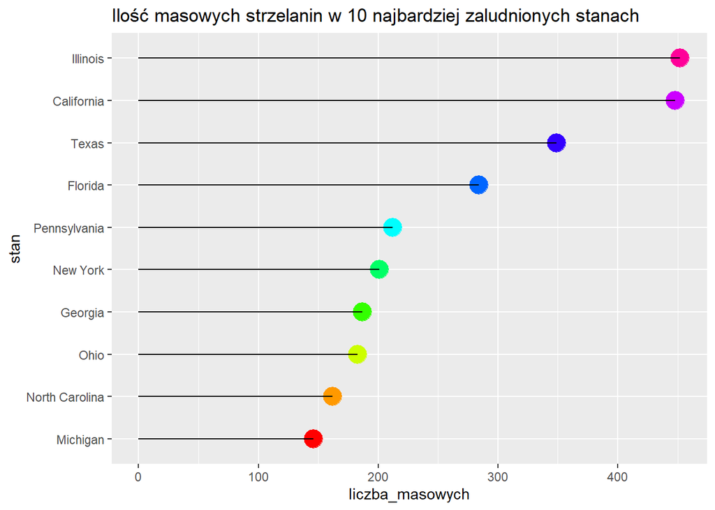

```r
wykresMasowe <- ggplot(masowe, aes(x = liczba_masowych, y = stan)) + geom_point(size = 6, colour = rainbow(10)) + geom_segment(aes(yend = stan, xend = 0))  + ggtitle("Ilość masowych strzelanin w 10 najbardziej zaludnionych stanach")
wykresMasowe
```

#### 4.5 Wskazanie stanu z największą liczbą masowych strzelanin

```r
top_n(masowe, 1)
```

```
##       stan liczba_masowych
## 1 Illinois             452
```

#### 4.6 Wskazanie stanu z najmniejszą ilością masowych strzelanin

```r
top_n(masowe, -1)
```

```
##       stan liczba_masowych
## 1 Michigan             146
```

### 5. Analiza strzelanin w stanie California

W rozdziale 5 przeanalizujemy ataki z użyciem broni palnej w najbardziej zaludnionym stanie — Californi. Dla uproszczenia pominiemy strzelaniny, w których nikt nie został zabity ani zraniony.

#### 5.1 Utworzenie ramki danych z podziałem na miasta i liczbę ofiar śmiertelnych

```r
California1<- strzelaniny1 %>% select(stan, miasto, liczba_zabitych) %>% filter(liczba_zabitych>0, stan == "California") %>%  as.data.frame()
California1 <- California1[-1]
California1 <- aggregate(liczba_zabitych ~ miasto, California1, sum)
glimpse(California1)
```

```
## Rows: 840
## Columns: 2
## $ miasto          <chr> "Acampo", "Adelanto", "Agoura Hills", "Aguanga", "Alam~
## $ liczba_zabitych <dbl> 2, 12, 3, 9, 6, 1, 4, 12, 3, 4, 6, 4, 1, 75, 1, 4, 11,~
```

##### 5.1.2 Mediana i średnia liczby zabitych osób w miastach stanu California

Ze względu na bardzo dużą liczbę miast w stanie California wyświetlamy tylko 5 pierwszych wyników.

```r
calOfiary <- California1 %>% group_by(miasto) %>% summarise(srednia = mean(liczba_zabitych), mediana = median(liczba_zabitych))  %>%  as.data.frame()
head(calOfiary,5)
```

```
##         miasto srednia mediana
## 1       Acampo       2       2
## 2     Adelanto      12      12
## 3 Agoura Hills       3       3
## 4      Aguanga       9       9
## 5      Alameda       6       6
```

#### 5.2 Utworzenie ramki danych z podziałem na miasta i liczbę rannych ofiar

```r
California2<- strzelaniny1 %>% select(stan, miasto, liczba_zranionych) %>% filter(liczba_zranionych>0, stan == "California") %>%  as.data.frame()
California2 <- California2[-1]
California2 <- aggregate(liczba_zranionych ~ miasto, California2, sum)
glimpse(California2)
```

```
## Rows: 363
## Columns: 2
## $ miasto            <chr> "Acampo", "Adelanto", "Aliso Viejo", "Altadena", "Al~
## $ liczba_zranionych <dbl> 1, 2, 2, 2, 2, 9, 1, 22, 3, 1, 4, 3, 4, 8, 1, 5, 97,~
```

##### 5.2.1 Mediana i średnia liczby zranionych osób w miastach stanu California

```r
calRanni <- California2 %>% group_by(miasto) %>% summarise(srednia = mean(liczba_zranionych), mediana = median(liczba_zranionych))
head(calRanni,5)
```

```
## # A tibble: 5 x 3
##   miasto      srednia mediana
##   <chr>         <dbl>   <dbl>
## 1 Acampo            1       1
## 2 Adelanto          2       2
## 3 Aliso Viejo       2       2
## 4 Altadena          2       2
## 5 Alturas           2       2
```

#### 5.3 Wybranie 5 najbardziej zaludnionych miast stanu California

Kolejne analizy w rozdziale 5 będą opierać się na 5 najbardziej zaludnionych miastach stanu California.

```r
miastaCal <- c("Los Angeles", "San Diego", "San Jose", "San Francisco", "Fresno")
California3 <- California1 %>% filter( miasto %in% miastaCal)
California4 <- California2 %>% filter( miasto %in% miastaCal)
```

#### 5.4 Analiza liczby zabitych osób w 5 najbardziej zaludnionych miastach stanu California

##### 5.4.1 Utworzenie ramki danych ze zmiennych miasto oraz liczba zabitych wraz ze zsumowaniem liczby zabitych dla każdego miasta

```r
California3 <- California3 %>% filter(liczba_zabitych > 0)
California3 <- California3 %>% group_by(miasto) %>% summarise(liczba_zabitych = sum(liczba_zabitych)) %>%  as.data.frame()
California3 <- arrange(California3, liczba_zabitych)
California3
```

```
##          miasto liczba_zabitych
## 1      San Jose             222
## 2     San Diego             270
## 3 San Francisco             272
## 4        Fresno             414
## 5   Los Angeles            1287
```

##### 5.4.2 Przypisanie kolejności dla wartości w ramce danych

```r
California3$miasto <- factor(California3$miasto, levels = California3$miasto[order(California3$liczba_zabitych)])
```

##### 5.4.3 Utworzenie wykresu słupkowego

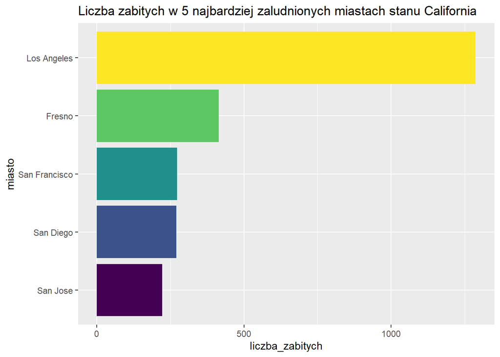

```r
wykresZabiciCalifornia <- ggplot(California3, aes(x = miasto, y = liczba_zabitych )) + geom_col(fill = viridis(5)) +  coord_flip() + ggtitle("Liczba zabitych w 5 najbardziej zaludnionych miastach stanu California")
wykresZabiciCalifornia
```

#### 5.5 Analiza liczby zranionych osób w 5 najbardziej zaludnionych miastach stanu California

##### 5.5.1 Utworzenie ramki danych ze zmiennych miasto oraz liczba zranionych wraz ze zsumowaniem liczby zranionych dla każdego miasta

```r
California4 <- California4 %>% filter(liczba_zranionych > 0)
California4 <- California4 %>% group_by(miasto) %>% summarise(liczba_zranionych = sum(liczba_zranionych)) %>%  as.data.frame()
California4 <- arrange(California4, liczba_zranionych)
California4
```

```
##          miasto liczba_zranionych
## 1      San Jose                32
## 2     San Diego                63
## 3 San Francisco                98
## 4        Fresno               105
## 5   Los Angeles               304
```

##### 5.5.2 Przypisanie kolejności dla wartości w ramce danych

```r
California4$miasto <- factor(California4$miasto, levels = California4$miasto[order(California4$liczba_zranionych)])
```

##### 5.5.3 Utworzenie wykresu słupkowego

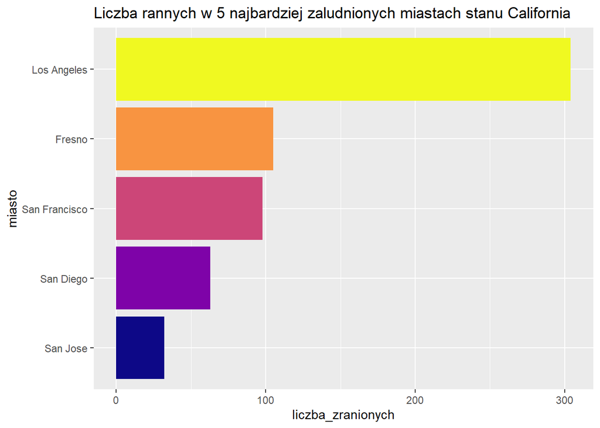

```r
wykresRanniCalifornia <- ggplot(California4, aes(x = miasto, y = liczba_zranionych )) + geom_col(fill = plasma(5)) +  coord_flip() + ggtitle("Liczba rannych w 5 najbardziej zaludnionych miastach stanu California")
wykresRanniCalifornia
```

### 6. Analiza ilości strzelanin, ofiar śmiertelnych i zranionych osób

```r
sumaZabitych<- sum(strzelaniny[,6], na.rm = TRUE)
sumaRannych<- sum(strzelaniny[,7], na.rm = TRUE)
sumaPoszkodowanych<- sumaRannych+sumaZabitych
liczbaStrzelanin<- nrow(strzelaniny[,1])
liczbaStrzelanin
```

```
## [1] 472820
```

```r
sumaZabitych
```

```
## [1] 135707
```

```r
sumaRannych
```

```
## [1] 265719
```

```r
sumaPoszkodowanych
```

```
## [1] 401426
```

#### 6.1 Stosunek zmiennych do siebie

```r
sumaZabitych/liczbaStrzelanin
```

```
## [1] 0.2870162
```

```r
sumaRannych/liczbaStrzelanin
```

```
## [1] 0.5619876
```

```r
sumaPoszkodowanych/liczbaStrzelanin
```

```
## [1] 0.8490038
```

```r
sumaZabitych/sumaRannych
```

```
## [1] 0.5107162
```

Powyższe dane mogą świadczyć o tym, że stosunek liczby osób zabitych i rannych jest bardzo niewielki w porównaniu do samej liczby ataków z użyciem broni palnej, co jest z pewnością pozytywnym wynikiem.

### 7. Analiza ataków z użyciem broni palnej na przestrzeni lat 2013-2022

#### 7.1 Przygotowanie danych

Przygotowane dane będą służyć do przeprowadzenia analiz w rozdziale 7.

```r
strzelaninyLata<- data.frame(strzelaniny[,c("data", "liczba_zabitych", "liczba_zranionych")])
strzelaninyLata<- separate(strzelaninyLata, data, c("rok", "miesiac", "dzien"), "-")
strzelaninyLata<- strzelaninyLata[,-c(2:3)]
head(strzelaninyLata, 5)
```

```
##    rok liczba_zabitych liczba_zranionych
## 1 2022               0                 1
## 2 2022               0                 1
## 3 2022               0                 1
## 4 2022               0                 2
## 5 2022               1                 0
```

#### 7.2 Analiza liczby ofiar śmiertelnych w latach 2013-2022

##### 7.2.1 Utworzenie ramki danych ze zmiennych rok i liczba_zabitych ze zsumowaniem liczby ofiar śmiertelnych w każdym roku

```r
strzelaninyLata1 <- strzelaninyLata %>% filter(liczba_zabitych > 0)
lataOfiary <- strzelaninyLata1 %>% group_by(rok) %>% summarise(liczba_zabitych = sum(liczba_zabitych)) %>%  as.data.frame()
lataOfiary <- arrange(lataOfiary, liczba_zabitych, rok)
lataOfiary
```

```
##     rok liczba_zabitych
## 1  2013             314
## 2  2022            7829
## 3  2014           12518
## 4  2015           13478
## 5  2016           15054
## 6  2018           15084
## 7  2019           15490
## 8  2017           15504
## 9  2020           19515
## 10 2021           20921
```

##### 7.2.2 Przypisanie kolejności dla wartości w ramce danych

```r
lataOfiary$rok <- factor(lataOfiary$rok, levels = lataOfiary$rok[order(lataOfiary$liczba_zabitych)])
```

##### 7.2.3 Utworzenie wykresu słupkowego

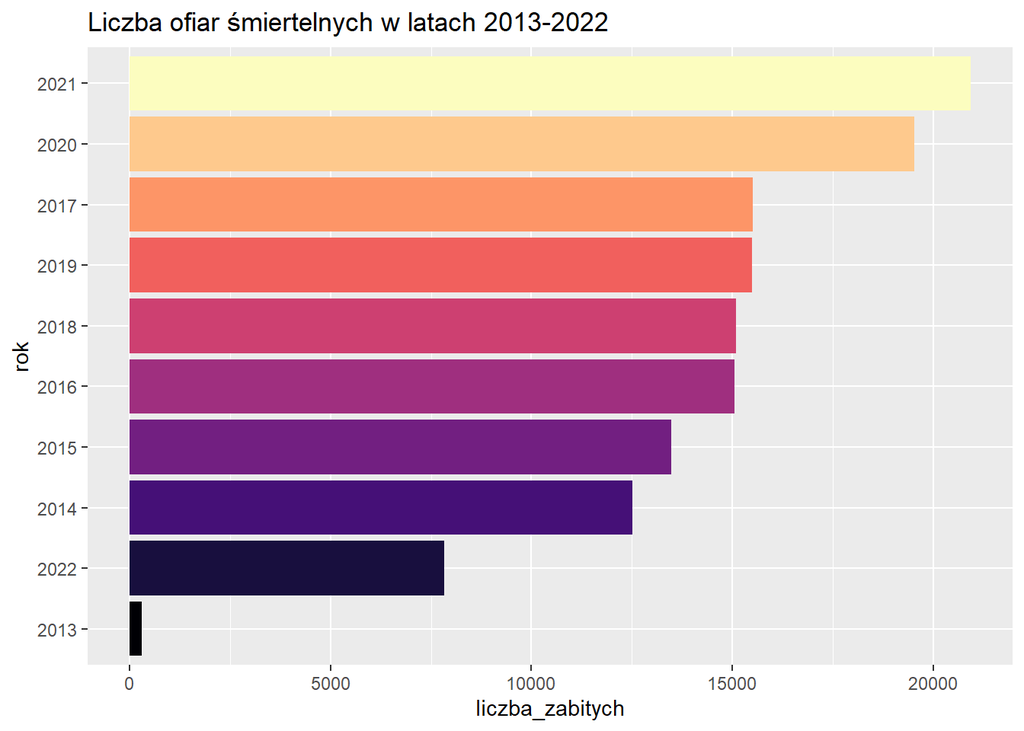

```r
wykresLataOfiary <- ggplot(lataOfiary, aes(x = rok, y = liczba_zabitych)) + geom_col(fill = magma(10))  +  coord_flip() + ggtitle("Liczba ofiar śmiertelnych w latach 2013-2022")
wykresLataOfiary
```

#### 7.3 Analiza liczby osób zranionych w latach 2013-2022

##### 7.3.1 Utworzenie ramki danych ze zmiennych rok i liczba_zranionych ze zsumowaniem liczby rannych ofiar w każdym roku

```r
strzelaninyLata2 <- strzelaninyLata %>% filter(liczba_zranionych > 0)
lataRanni <- strzelaninyLata2 %>% group_by(rok) %>% summarise(liczba_zranionych = sum(liczba_zranionych)) %>%  as.data.frame()
lataRanni <- arrange(lataRanni, liczba_zranionych, rok)
lataRanni
```

```
##     rok liczba_zranionych
## 1  2013               981
## 2  2022             14615
## 3  2014             22948
## 4  2015             26937
## 5  2018             28705
## 6  2019             30191
## 7  2016             30551
## 8  2017             30691
## 9  2020             39531
## 10 2021             40569
```

##### 7.3.2 Przypisanie kolejności dla wartości w ramce danych

```r
lataRanni$rok <- factor(lataRanni$rok, levels = lataRanni$rok[order(lataRanni$liczba_zranionych)])
```

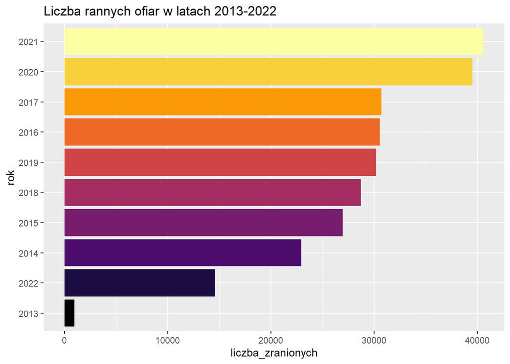

```r
wykresLataRanni <- ggplot(lataRanni, aes(x = rok, y = liczba_zranionych)) + geom_col(fill = inferno(10))  +  coord_flip() + ggtitle("Liczba rannych ofiar w latach 2013-2022")
wykresLataRanni
```

#### 7.4 Analiza liczby masowych strzelanin w latach 2013-2022

##### 7.4.1 Dodanie kryterium definującego nową kolumnę

```r
strzelaninyLata3 <- strzelaninyLata %>% mutate(liczba_trafionych2 = liczba_zabitych+liczba_zranionych)
strzelaninyLata3 <- strzelaninyLata3 %>% filter(liczba_trafionych2 > 3)
```

##### 7.4.2 Utworzenie ramki danych ze zmiennych rok oraz liczba masowych strzelanin wraz ze zsumowaniem liczby masowych strzelanin

```r
lataMasowe <- strzelaninyLata3 %>% group_by(rok) %>% summarise(liczba_masowych2 = length(liczba_trafionych2)) %>%  as.data.frame()
lataMasowe <- arrange(lataMasowe, liczba_masowych2, rok)
lataMasowe
```

```
##     rok liczba_masowych2
## 1  2013              258
## 2  2022              262
## 3  2015              409
## 4  2014              429
## 5  2018              442
## 6  2017              446
## 7  2016              479
## 8  2019              503
## 9  2020              725
## 10 2021              827
```

##### 7.4.3 Przypisanie kolejności dla wartości w ramce danych

```r
lataMasowe$rok <- factor(lataMasowe$rok, levels = lataMasowe$rok[order(lataMasowe$liczba_masowych2)])
```

##### 7.4.4 Utworzenie wykresu punktowego

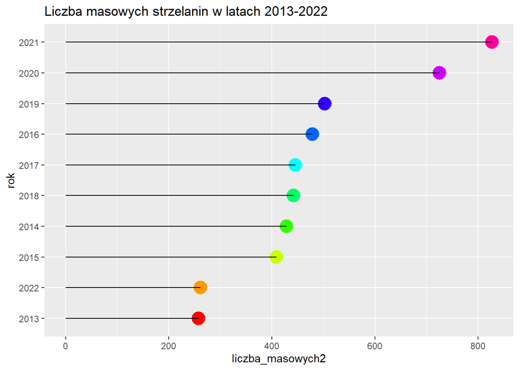

```r
wykresLataMasowe <- ggplot(lataMasowe, aes(x = liczba_masowych2, y = rok)) + geom_point(size = 6, colour = rainbow(10)) + geom_segment(aes(yend = rok, xend = 0))  + ggtitle("Liczba masowych strzelanin w latach 2013-2022")
wykresLataMasowe
```

```r
options(warn = defaultW)
```